# explo06-Compare-treated.Rmd

Marie Plessz

# comparer les traités et les controles selectionnées pour l’analyse DiD

(https://vincentarelbundock.github.io/modelsummary/)

```r
library(haven)
library(tidyverse)
library(questionr)
library(gtsummary)
library(glue)
library(MatchIt)
library(modelsummary)
library(gt)

options(OutDec= ",",
                    encoding = "utf-8")

tag <- "Programme: explo06-Compare-treated.Rmd"
```

# préparation des données —–

```r
data_sehar <- read_dta("Data-Sehar/Data/STUDYPOP_INC2017_NEW_V3.dta")
data_comp <- read_dta("Data/Cree/HDR6_01_tous.dta", col_select =
                                                c("proj_isp", "typmen", "prive", "inde", "aveccouple01",
                                                    "avecenf01", "age_cl", "homme"))

data_orig <- inner_join(data_sehar, data_comp, by = "proj_isp") %>%
    rename(typmen = typmen.y,
                 typmen_sehar = typmen.x)

# variables qui doivent être des facteurs :
to_factor <- data_orig %>%
    select( -fm_incluage, -BMI_INC, -year) %>%
    map_lgl(is.numeric) %>%
        names


df <- data_orig %>%
    mutate_at(to_factor, as_factor) %>%
    mutate_if(is.factor, fct_drop) %>%

# recodages
    mutate(cho17 = case_when(emploi ==2  ~ 1,
                                                     emploi == 1 ~ 0)) %>%
    mutate(sante =fct_lump(EtatSante_INC,3, other_level = "4-8/8")) %>%
    mutate(edu = case_when(edu == 0 ~ "<Bac",
                                                 edu == 1 ~ "Bac",
                                                 edu == 2 ~ ">Bac")) %>%
    mutate(edu = factor(edu, levels = c("<Bac", "Bac", ">Bac" ))) %>%
    mutate(FinSit = case_when(FinSit == "1" ~ "Difficultés",
                                                        FinSit == "2" ~ "Parfois difficultés",
                                                        FinSit == "3" ~ "Pas de difficultés"))
```

# qui est traité : qui est devient chômeur

```r
# un simple tableau croisé ==< ma solution préférée.
df %>% select( homme, aveccouple01, avecenf01, age_cl, edu, region, FinSit,
                             prive, inde,
                             sante, ALCAB_INC, Tabac_INC, H_FV_INC, H_POISS_INC, cho17) %>%
    tbl_summary(by  = cho17 ,
                            statistic = all_categorical() ~ "{p}%",
                            digits = all_categorical() ~ 1) %>%  add_p()
```

| **Characteristic** | **0**, N = 28 557<sup>1</sup> | **1**, N = 766<sup>1</sup> | **p-value**<sup>2</sup> |
| --- | --- | --- | --- |
| Sexe: homme? |  |  | 0,002 |
| Femme | 52,7% | 58,4% |  |
| Homme | 47,3% | 41,6% |  |
| Vit en couple? 0/1 |  |  | <0,001 |
| CoupleNON | 21,4% | 33,4% |  |
| CoupleOUI | 78,6% | 66,6% |  |
| Unknown | 206 | 9 |  |
| Vit avec enfants? 0/1 |  |  | <0,001 |
| EnfantNON | 37,6% | 52,8% |  |
| EnfantOUI | 62,4% | 47,2% |  |
| Unknown | 891 | 33 |  |
| Classe d'age inclusion |  |  | <0,001 |
| 18-29 ans | 10,7% | 20,6% |  |
| 30-39 ans | 27,7% | 26,2% |  |
| 40-49 ans | 34,8% | 23,8% |  |
| 50 ans et plus | 26,8% | 29,4% |  |
| edu |  |  | <0,001 |
| <Bac | 13,6% | 20,8% |  |
| Bac | 13,5% | 18,3% |  |
| >Bac | 72,9% | 61,0% |  |
| Région du CES |  |  | <0,001 |
| Paris | 17,4% | 26,9% |  |
| Nord Est | 14,4% | 11,9% |  |
| Sud-ouest | 21,1% | 20,4% |  |
| Sud-Est | 15,2% | 12,5% |  |
| Bretagne | 16,3% | 13,2% |  |
| Centre | 15,6% | 15,1% |  |
| FinSit |  |  | <0,001 |
| Difficultés | 3,7% | 7,9% |  |
| Parfois difficultés | 26,4% | 37,7% |  |
| Pas de difficultés | 70,0% | 54,4% |  |
| Unknown | 198 | 7 |  |
| Employeur prive? |  |  | <0,001 |
| Public ou assimile | 49,7% | 14,3% |  |
| Prive | 50,3% | 85,7% |  |
| Unknown | 2 428 | 114 |  |
| Statut independant? |  |  | 0,6 |
| Salarie | 94,1% | 93,5% |  |
| Independant | 5,9% | 6,5% |  |
| Unknown | 1 134 | 24 |  |
| sante |  |  | <0,001 |
| 1 | 11,6% | 9,1% |  |
| 2 | 45,5% | 35,9% |  |
| 3 | 29,1% | 31,6% |  |
| 4-8/8 | 13,8% | 23,4% |  |
| ALCAB_INC |  |  | <0,001 |
| 0 | 92,2% | 86,2% |  |
| 1 | 7,8% | 13,8% |  |
| Tabac_INC |  |  | <0,001 |
| 0 | 82,1% | 73,6% |  |
| 1 | 17,9% | 26,4% |  |
| H_FV_INC |  |  | 0,7 |
| 0 | 82,5% | 82,0% |  |
| 1 | 17,5% | 18,0% |  |
| H_POISS_INC |  |  | 0,014 |
| 0 | 31,9% | 36,2% |  |
| 1 | 68,1% | 63,8% |  |

<sup>*1*</sup> Statistics presented: % <sup>*2*</sup> Statistical tests performed: chi-square test of independence

# une régression logistique

```r
fit1 <-
    glm(formula = cho17 ~ homme + typmen + age10inc + edu +
                region + FinSit , family = binomial(), data = df)
summary(fit1)
```

```
##
## Call:
## glm(formula = cho17 ~ homme + typmen + age10inc + edu + region +
##     FinSit, family = binomial(), data = df)
##
## Deviance Residuals:
##     Min       1Q   Median       3Q      Max
## -0,7293  -0,2538  -0,1990  -0,1601   3,1348
##
## Coefficients:
##                           Estimate Std. Error z value Pr(>|z|)
## (Intercept)               -1,56943    0,21818  -7,193 6,33e-13 ***
## hommeHomme                -0,23777    0,07758  -3,065  0,00218 **
## typmenCouple sans enfant   0,24088    0,10312   2,336  0,01949 *
## typmenCelib avec enfant    0,26554    0,16557   1,604  0,10876
## typmenCelib sans enfant    0,57420    0,10824   5,305 1,13e-07 ***
## typmenMenage complexe      0,75805    0,15373   4,931 8,19e-07 ***
## age10inc30-39 ans         -0,51906    0,11765  -4,412 1,02e-05 ***
## age10inc40-49 ans         -0,87543    0,12543  -6,980 2,96e-12 ***
## age10inc50-59 ans         -0,56471    0,11763  -4,801 1,58e-06 ***
## age10inc60-69 ans          0,03862    0,38101   0,101  0,91926
## eduBac                    -0,19347    0,12570  -1,539  0,12376
## edu>Bac                   -0,66513    0,10791  -6,164 7,10e-10 ***
## regionNord Est            -0,68308    0,13562  -5,037 4,74e-07 ***
## regionSud-ouest           -0,50541    0,11486  -4,400 1,08e-05 ***
## regionSud-Est             -0,64708    0,13110  -4,936 7,98e-07 ***
## regionBretagne            -0,67961    0,13235  -5,135 2,82e-07 ***
## regionCentre              -0,53690    0,12587  -4,265 2,00e-05 ***
## FinSitParfois difficultés -0,36411    0,15030  -2,423  0,01541 *
## FinSitPas de difficultés  -0,87525    0,14917  -5,868 4,42e-09 ***
## ---
## Signif. codes:  0 '***' 0,001 '**' 0,01 '*' 0,05 '.' 0,1 ' ' 1
##
## (Dispersion parameter for binomial family taken to be 1)
##
##     Null deviance: 6799,0  on 28226  degrees of freedom
## Residual deviance: 6483,8  on 28208  degrees of freedom
##   (1096 observations deleted due to missingness)
## AIC: 6521,8
##
## Number of Fisher Scoring iterations: 7
```

```r
fit2 <-
    glm(formula = cho17 ~ homme + typmen + age10inc + edu + region+ FinSit + sante + ALCAB_INC + Tabac_INC , family = binomial(), data = df)

tbl_regression(fit1, exponentiate = T, show_single_row = c(homme) ) %>%
    modify_table_header(
        column = ci,
        hide = TRUE)
```

| **Characteristic** | **OR**<sup>1</sup> | **p-value** |
| --- | --- | --- |
| Sexe: homme? | 0,79 | 0,002 |
| Type de menage |  |  |
| Couple + enfant(s) | — |  |
| Couple sans enfant | 1,27 | 0,019 |
| Celib avec enfant | 1,30 | 0,11 |
| Celib sans enfant | 1,78 | <0,001 |
| Menage complexe | 2,13 | <0,001 |
| Classe d'age inclusion |  |  |
| 18-29 ans | — |  |
| 30-39 ans | 0,60 | <0,001 |
| 40-49 ans | 0,42 | <0,001 |
| 50-59 ans | 0,57 | <0,001 |
| 60-69 ans | 1,04 | >0,9 |
| edu |  |  |
| <Bac | — |  |
| Bac | 0,82 | 0,12 |
| >Bac | 0,51 | <0,001 |
| Région du CES |  |  |
| Paris | — |  |
| Nord Est | 0,51 | <0,001 |
| Sud-ouest | 0,60 | <0,001 |
| Sud-Est | 0,52 | <0,001 |
| Bretagne | 0,51 | <0,001 |
| Centre | 0,58 | <0,001 |
| FinSit |  |  |
| Difficultés | — |  |
| Parfois difficultés | 0,69 | 0,015 |
| Pas de difficultés | 0,42 | <0,001 |

<sup>*1*</sup> OR = Odds Ratio, CI = Confidence Interval

# examiner les déséquilibres avant appariement (package MatchIt)

/! cas complets uniquement.

```r
dfcc <- df %>%
    select(homme, aveccouple01, avecenf01, age_cl, edu, region, FinSit,
                                            prive, inde,
                                            sante, ALCAB_INC, Tabac_INC, H_FV_INC, H_POISS_INC, cho17) %>%
    drop_na()

m.out0 <- matchit(cho17 ~ homme + aveccouple01 + avecenf01 + age_cl + edu + region+ FinSit + sante + ALCAB_INC + Tabac_INC, data = dfcc,
                                    method = NULL, distance = "glm")

summary(m.out0)
```

```
##
## Call:
## matchit(formula = cho17 ~ homme + aveccouple01 + avecenf01 +
##     age_cl + edu + region + FinSit + sante + ALCAB_INC + Tabac_INC,
##     data = dfcc, method = NULL, distance = "glm")
##
## Summary of Balance for All Data:
##                           Means Treated Means Control Std. Mean Diff.
## distance                         0,0396        0,0242          0,4851
## hommeFemme                       0,5475        0,5100          0,0755
## hommeHomme                       0,4525        0,4900         -0,0755
## aveccouple01CoupleNON            0,3492        0,2057          0,3010
## aveccouple01CoupleOUI            0,6508        0,7943         -0,3010
## avecenf01EnfantNON               0,5426        0,3743          0,3380
## avecenf01EnfantOUI               0,4574        0,6257         -0,3380
## age_cl18-29 ans                  0,2148        0,1067          0,2632
## age_cl30-39 ans                  0,2574        0,2787         -0,0488
## age_cl40-49 ans                  0,2475        0,3521         -0,2422
## age_cl50 ans et plus             0,2803        0,2625          0,0396
## edu<Bac                          0,1869        0,1301          0,1456
## eduBac                           0,1951        0,1378          0,1446
## edu>Bac                          0,6180        0,7321         -0,2347
## regionParis                      0,2689        0,1705          0,2218
## regionNord Est                   0,1164        0,1457         -0,0915
## regionSud-ouest                  0,2098        0,2117         -0,0047
## regionSud-Est                    0,1279        0,1530         -0,0752
## regionBretagne                   0,1377        0,1634         -0,0745
## regionCentre                     0,1393        0,1556         -0,0470
## FinSitDifficultés                0,0770        0,0366          0,1519
## FinSitParfois difficultés        0,3590        0,2595          0,2074
## FinSitPas de difficultés         0,5639        0,7039         -0,2823
## sante1                           0,0967        0,1176         -0,0706
## sante2                           0,3574        0,4551         -0,2040
## sante3                           0,3164        0,2921          0,0522
## sante4-8/8                       0,2295        0,1352          0,2243
## ALCAB_INC0                       0,8607        0,9230         -0,1801
## ALCAB_INC1                       0,1393        0,0770          0,1801
## Tabac_INC0                       0,7393        0,8241         -0,1930
## Tabac_INC1                       0,2607        0,1759          0,1930
##                           Var. Ratio eCDF Mean eCDF Max
```

[output cut: 24 more lines]

```
## sante2                             .    0,0978   0,0978
## sante3                             .    0,0243   0,0243
## sante4-8/8                         .    0,0943   0,0943
## ALCAB_INC0                         .    0,0624   0,0624
## ALCAB_INC1                         .    0,0624   0,0624
## Tabac_INC0                         .    0,0847   0,0847
## Tabac_INC1                         .    0,0847   0,0847
##
##
## Sample Sizes:
##           Control Treated
## All         24213     610
## Matched     24213     610
## Unmatched       0       0
## Discarded       0       0
```

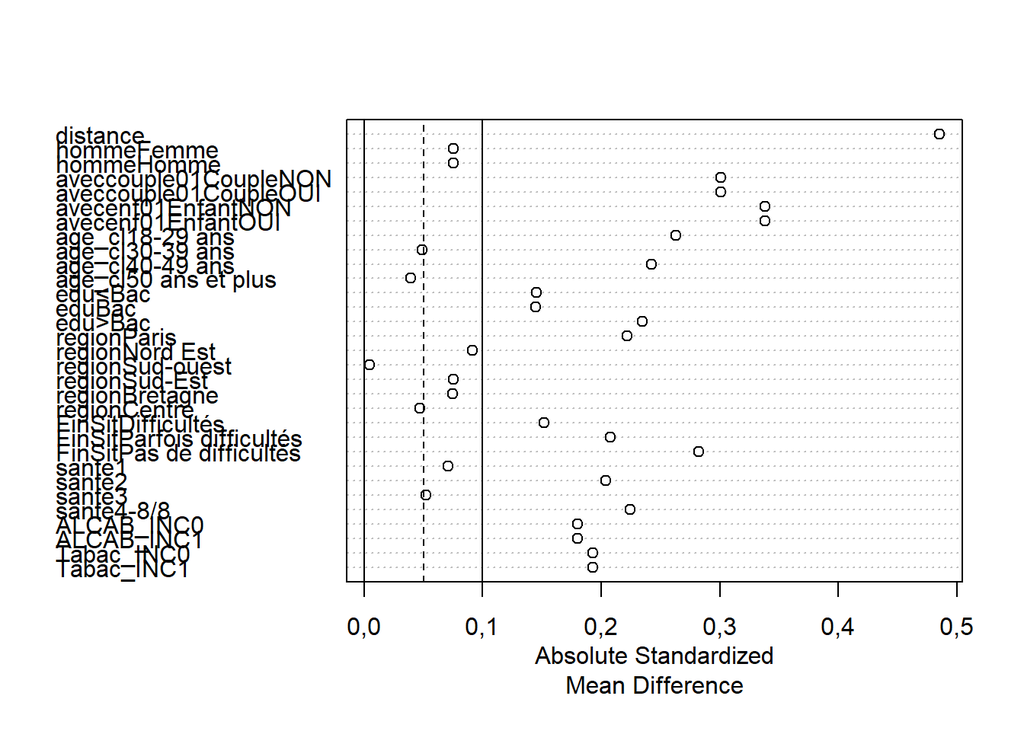

```r
plot(summary(m.out0))
```

==> l’output n’est pas plus clair que le bon vieux tableau croisé, et le grpaphe non plus.

# DES essais sur l’ALCOOL

## évolution des pratiques ———–

effet relatif de la continuité dans la pratique et du chômage

```r
data_orig <- read_dta("Data-Sehar/Data/ALCOHOL.dta")

freq(data_orig$ALCAB_2017)
```

|  | n | % | val% |
| --- | --- | --- | --- |
| 0 | 25808 | 88,0 | 88,8 |
| 1 | 3270 | 11,2 | 11,2 |
| NA | 245 | 0,8 | NA |

```r
freq(data_orig$ALCAB_INC)
```

|  | n | % | val% |
| --- | --- | --- | --- |
| 0 | 26977 | 92 | 92 |
| 1 | 2346 | 8 | 8 |

```r
lprop(table(data_orig$ALCAB_2017,data_orig$ALCAB_INC))
```

```
##
##            0     1     Total
##   0         95,4   4,6 100,0
##   1         65,1  34,9 100,0
##   Ensemble  92,0   8,0 100,0
```

```r
fit <- glm(ALCAB_2017 ~ ALCAB_INC, data = data_orig, family = binomial)
odds.ratio(fit)
```

|  | OR | 2,5 % | 97,5 % | p |
| --- | --- | --- | --- | --- |
| (Intercept) | 0,08652909 | 0,08275931 | 0,09042083 | 0 |
| ALCAB_INC | 11,05265148 | 10,07673646 | 12,12415071 | 0 |

```r
fit1 <- glm(ALCAB_2017 ~ Treated, data = data_orig, family = binomial)
odds.ratio(fit1)
```

|  | OR | 2,5 % | 97,5 % | p |
| --- | --- | --- | --- | --- |
| (Intercept) | 0,1250248 | 0,1204555 | 0,1297212 | 0,000000e+00 |
| Treated | 1,5513612 | 1,2680416 | 1,8825418 | 1,300223e-05 |

```r
fit2 <- glm(ALCAB_2017 ~ ALCAB_INC + Treated, data = data_orig, family = binomial)
odds.ratio(fit2)
```

|  | OR | 2,5 % | 97,5 % | p |
| --- | --- | --- | --- | --- |
| (Intercept) | 0,08593055 | 0,08214762 | 0,08983753 | 0,00000000 |
| ALCAB_INC | 11,00252083 | 10,03021899 | 12,07011772 | 0,00000000 |
| Treated | 1,29448327 | 1,03716335 | 1,60301252 | 0,02006505 |

## un graphique pour l’alcool —–

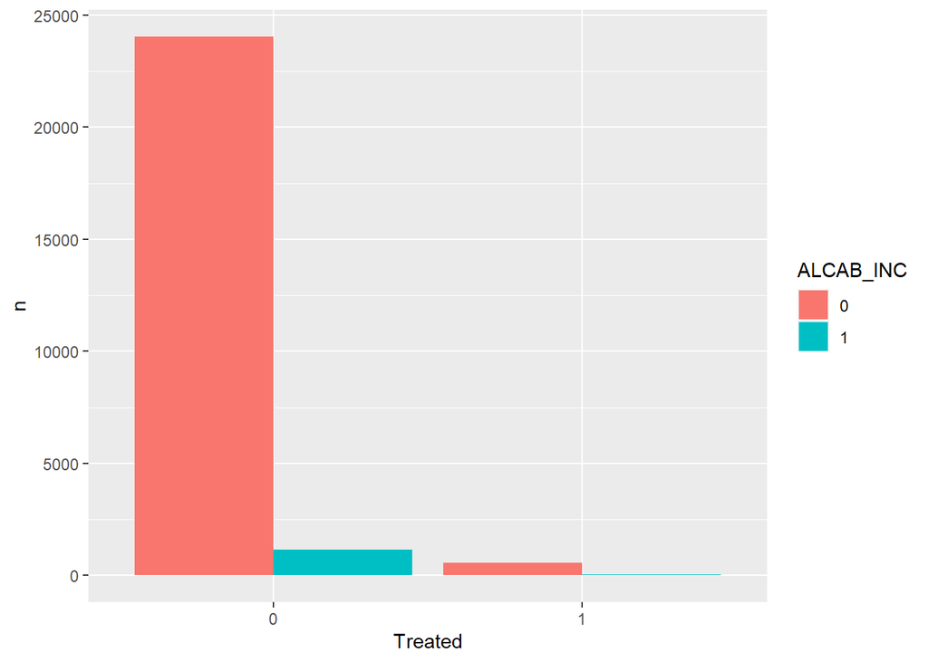

```r
df <- data_orig %>%
    select(ALCAB_INC, Treated, ALCAB_2017) %>%
    mutate_all(as.factor)

df %>%
    group_by(ALCAB_INC, Treated, ALCAB_2017) %>%
    count %>%
    ggplot() +
    geom_bar(aes(x = Treated , fill = ALCAB_INC , y = n),
                     stat = "identity",
                     position = "dodge"
    )
```

==> pas merveilleux

## graphique avec des données “long” ——–

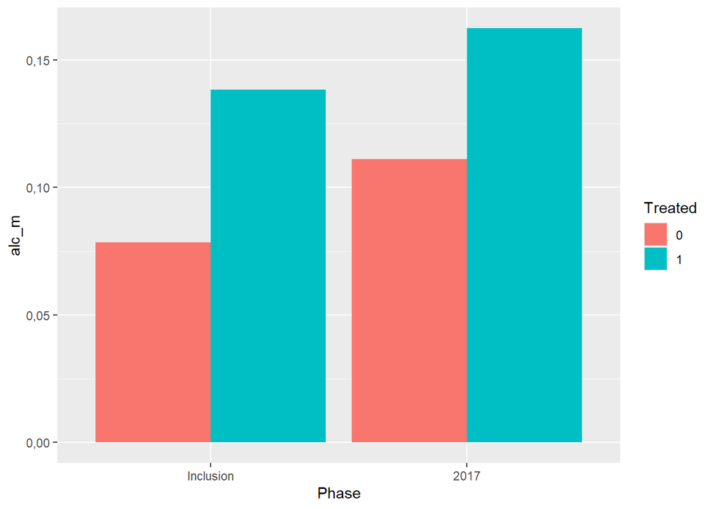

```r
dfl <-df %>%
    pivot_longer(c(ALCAB_INC, ALCAB_2017)   ,
                             names_to = "Phase", values_to = "alc") %>%
    mutate(Phase = fct_recode(Phase, "Inclusion" ="ALCAB_INC",
                                                         "2017" = "ALCAB_2017")) %>%
    mutate(Phase = relevel(Phase, ref = "Inclusion" )) %>%
    drop_na()

dfl %>% group_by(Phase, Treated) %>%
    mutate(alc = as.numeric(as.character(alc))) %>%
    summarise(alc_m = mean(alc)) %>%
    ggplot() +
    geom_bar(aes(x = Phase, y =  alc_m, fill = Treated),
                     stat = "identity",
                     position = "dodge")
```

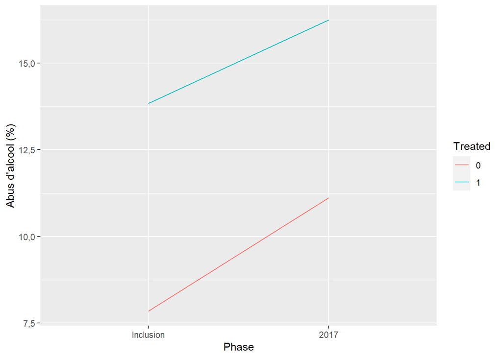

```r
# graphique avec des lignes

dfl %>% mutate(Alcool = 100* as.numeric(as.character(alc))) %>%
    ggplot() +
    geom_line(aes(x = Phase, y =  Alcool, group = Treated, color = Treated),
                        stat = "summary", fun= "mean") +
                        ylab("Abus d'alcool (%)")
```

## examiner les données appariées par Sehar—–

```r
alcm_orig <- read_dta("Data-Sehar/Data/match_alc.dta")

# variables qui doivent être des facteurs :
to_factor <- alcm_orig  %>%
    select( -fm_incluage, -BMI_INC, -year, -cem_weights) %>%
    map_lgl(is.numeric) %>%
    names


df <- alcm_orig  %>%
    mutate_at(to_factor, as_factor) %>%
    mutate_if(is.factor, fct_drop)


fit <- glm(ALCAB_2017 ~ ALCAB_INC, data = df, family = binomial)
odds.ratio(fit)
```

|  | OR | 2,5 % | 97,5 % | p |
| --- | --- | --- | --- | --- |
| (Intercept) | 0,08652909 | 0,08275931 | 0,09042083 | 0 |
| ALCAB_INC1 | 11,05265148 | 10,07673646 | 12,12415071 | 0 |

```r
fit1 <- glm(ALCAB_2017 ~ Treated, data = df, family = binomial)
odds.ratio(fit1)
```

|  | OR | 2,5 % | 97,5 % | p |
| --- | --- | --- | --- | --- |
| (Intercept) | 0,1250248 | 0,1204555 | 0,1297212 | 0,000000e+00 |
| Treated1 | 1,5513612 | 1,2680416 | 1,8825418 | 1,300223e-05 |

```r
fit2 <- glm(ALCAB_2017 ~ ALCAB_INC + Treated, data = df, family = binomial)
odds.ratio(fit2)
```

|  | OR | 2,5 % | 97,5 % | p |
| --- | --- | --- | --- | --- |
| (Intercept) | 0,08593055 | 0,08214762 | 0,08983753 | 0,00000000 |
| ALCAB_INC1 | 11,00252083 | 10,03021899 | 12,07011772 | 0,00000000 |
| Treated1 | 1,29448327 | 1,03716335 | 1,60301252 | 0,02006505 |

```r
fit3 <-  glm(ALCAB_2017 ~ ALCAB_INC + Treated  , data = df, weights = cem_weights, family = binomial)
odds.ratio(fit3)
```

|  | OR | 2,5 % | 97,5 % | p |
| --- | --- | --- | --- | --- |
| (Intercept) | 0,09669543 | 0,09145954 | 0,1021461 | 0,00000000 |
| ALCAB_INC1 | 10,25001537 | 9,25923427 | 11,3494344 | 0,00000000 |
| Treated1 | 1,21854897 | 0,96423346 | 1,5260162 | 0,09121504 |

```r
fit4 <-glm(ALCAB_2017 ~ ALCAB_INC + Treated +
                        L_POISS_INC + Tabac_INC + L_FV_INC + BMICat_INC + EtatSante_R_INC + chomagepast + cspvol + typmen + edu + fm_sexe + region  + FinSit + age10inc + INCDATEn
                     , data = df, weights = cem_weights, family = binomial)
or4 <- odds.ratio(fit4)
```

## le beau talbeau ——

avec le package `modelsummary`, qui peut ensuite être retravaillé avec les autres packages à tableau. Je n’affiche que les 2 coeffs intéressants : l’effet du traitement, et l’effet bien plus fort de la pratique antérieure.

```r
modelsummary(fit4,  statistic = "p.value", statistic_vertical = FALSE, stars = T, exponentiate = T, coef_omit = "[^ALCAB_INC1|Treated1]",  gof_omit=".*")
```

|  | Model 1 |
| --- | --- |
| ALCAB_INC1 | 9,054*** (0,000) |
| Treated1 | 1,215 (0,113) |

* p < 0,1, ** p < 0,05, *** p < 0,01

```r
tab <- modelsummary(list(fit3,fit4),
                         statistic = "p.value", stars = T,
                         statistic_vertical = FALSE,
                         exponentiate = T,
                         coef_omit = "[^ALCAB_INC1|Treated1]",
                         gof_omit=".*",
                          notes = c("Données appariées",
                                            tag),
                         title = "Surconso alccol en 2017: effet du chômage et de la conso à l'inclusion OR et p-value",
                         output = "gt")

tab %>%  cols_label(
    "Model 1" = "Sans ajustement",
    "Model 2" = "Avec ajustement"
  )
```

Surconso alccol en 2017: effet du chômage et de la conso à l'inclusion OR et p-value

|  | Sans ajustement | Avec ajustement |
| --- | --- | --- |
| ALCAB_INC1 | 10,250*** (0,000) | 9,054*** (0,000) |
| Treated1 | 1,219* (0,091) | 1,215 (0,113) |

* p < 0,1, ** p < 0,05, *** p < 0,01  
Données appariées  
Programme: explo06-Compare-treated.Rmd

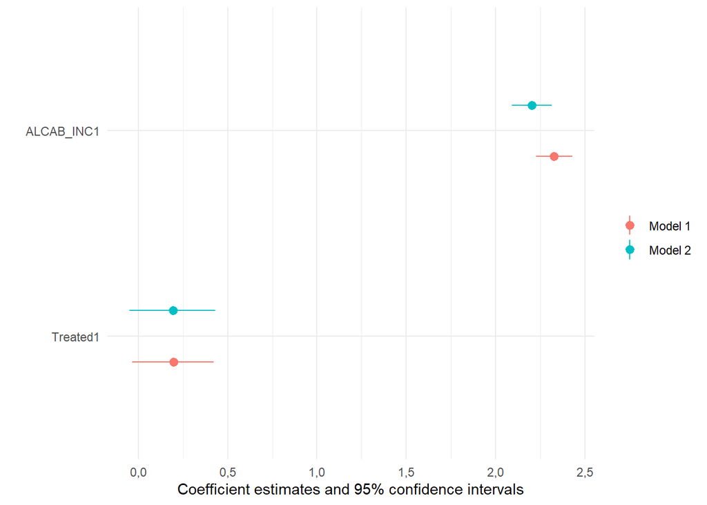

```r
modelplot(list(fit3,fit4), coef_omit = "[^ALCAB_INC1|Treated1]")
```

coef_omit : séparer par une barre les coefs à afficher. ne pas oublier le N° de la modalité de référence.

on peut donner une liste de modèles.

l’option , exponentiate = TRUE existe mais elle calcule les IC en prenant simplement l’exponentielle, ce qui n’est pas correct. les p sont donc pê faux pour les Odds-ratio. en même temps je trouve que Sehar sous Stata et qu’avec la fonction odds.ratio() du package questionr…

==> je retrouve les résultats de Sehar.

liste des fichiers à fusionner - merger tous les fichiers - merger aussi les qq variables de HDR6-01 : typmen, public, inde - faire une belle série de graphes - et une belle série d’odds-ratio

- ALCOHOL
- FV
- FISH
- SANTE
- TOBACCO
- FRETOBdta
- BMI